BACK TO MAIN MENU

- Numeric Summary of Quantitative Data
- Graphical Summary of Quantitative Data
- Introduction to Data Day 1

# Numeric Summary of Quantitative Data

Quantitative data is best summarized with the five-number summary and the mean.

- The five-number summary are the minimum, first quartile, median, third quartile and maximum.
- The median is the number located in the middle of the sorted data. Therefore, half of the data is below the *median* and the other half above.
- The first quartile, *(Q1)*, is a number with one quarter (or 25%) of the data below and 75% above.
- Similarly, the third quartile, *(Q3)*, is a number with three quarter (or 75%) of the data below and 25% above.

In R, display the numeric summary of the variable **weight** in the data frame **chickwts**.

> Step 1: Open R

> Step 2: In R Console, type **library(Rcmdr)**, and hit ENTER.

Go to Step 5 if data is already opened

> Step 3: Open data, click on DATA > DATA IN PACKAGES > Read data set from an attached package

> Step 4: Enter name of data set: **chickwts**

> Step 5: Click on STATISTICS > SUMMARIES > NUMERICAL SUMMARIES

> Step 6: Select the variable **weight** and hit OK

```
     mean      sd IQR  0%   25% 50%   75% 100%  n
 261.3099 78.0737 119 108 204.5 258 323.5  423 71
```

Answer the following questions:

- What is the weight range in the sample?
- What is the approximate weight of the heavier chicken in the sample?
- What is the average weight?
- Are there chicken with unusual weight?
- Do the feed supplements help these chicken to growth fast?

# Graphical Summary of Quantitative Data

Plots of quantitative data help to visualize the distribution and unusual observations.

**HISTOGRAM**

- **Histograms** display the shape of the data distribution *(symmetry, skewness, modes)*.
- Histograms are similar to bar charts. Each bar is a **class intervals** with height equal to the interval’s frequency. *(Frequency histogram)*

> In R, click on GRAPHS > HISTOGRAM. Select variable. Choose the OPTION tab to add axes labels and title. Hit OK.

**BOX PLOT**

- A **Box plot** complements the histogram with the visualization of the five-number summary.
- Box plots are effective for the identification of **outliers** *(unusual observations)*

> In R, click on GRAPHS > BOXPLOT. Select variable. Choose the OPTION tab to add axes labels and title. Hit OK.

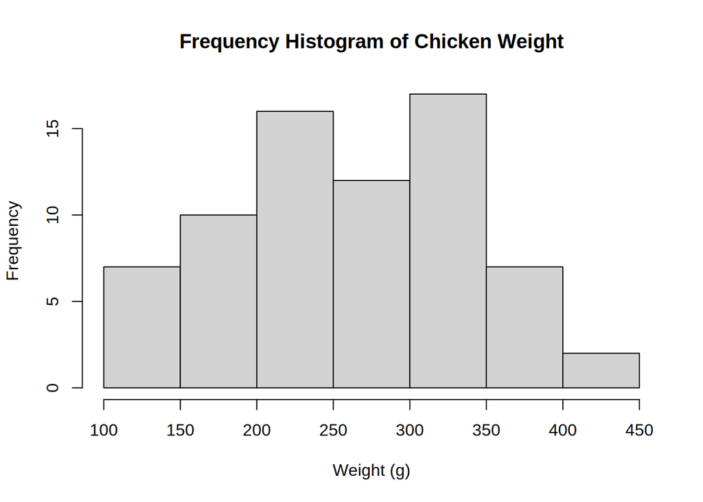

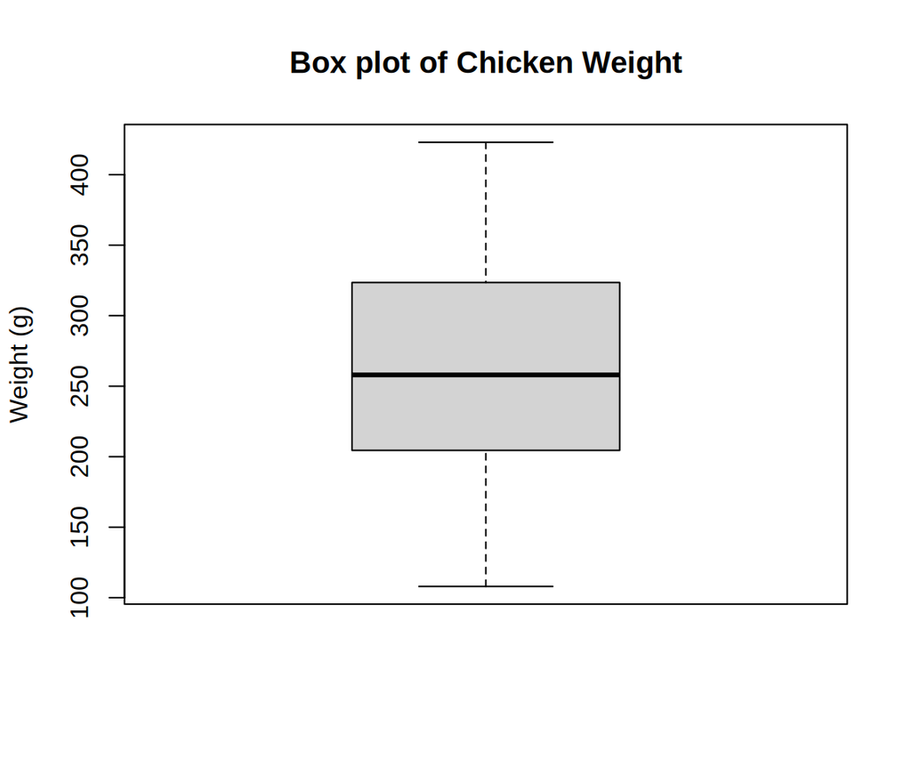

# Introduction to Data Day 1

Step 1: Start R

> Open R and type **library(Rcmdr)** in the R Console. Hit ENTER to lunch the R GUI.

Step 2: Prepare your MS Word document.

- Open a new **Word** document.
- Click on the INSERT > Header > Three Column Header
- On each column type: *your name*, *Section 1*, and your instructor name, *A. Falchettore*.
- Save your Word document (FILE > SAVE AS) with the following format: your last name, your first initial, your student ID number, and the letters DD1.
- So, if you are Sue Jones ID 99999999, your document would be saved as **joness99999999DD1**

Step 3: Access Brightspace and read the project instructions **BEFORE** downloading the data file for analysis

**Importing Data to R Studio (Practice)**

There is a link to the **sleep** data set in BRIGHTSPACE. Download file **ONLY**. DO NOT OPEN.

> In R, click on DATA > IMPORT DATA > FROM EXCEL FILE. Write a name for the data set and hit OK.

> Browse your data and click OK.

**Instructions:**

Today, you are going to do two main things:

- Look at all the variables. Choose *ONE* quantitative and *ONE* categorical variables. Inspect them (*TWO* in total) using R. Describe each one as thoroughly as you can. *(Number of variables in actual Data Day 1 are different)*
- Tell me what question (for each of the chosen variables) you think was asked to result in the answers that were given.

The description for each variable should have this format:

- Name of Variable.
- Question that could have been asked to obtain the responses in this variable.
- Description of tables and charts in layman terms.
- Paste summary tables and charts from R Studio.

**Taking Screenshots of Tables and Charts**

- On the keyboard, press simultaneously the keys: **Windows Logo**, **Shift**, **S**.
- Select the area to take the screenshot.
- Paste in MS Word.

**Recommendations (Data Day)**

- Read the instructions CAREFULLY. Ask questions if something is not clear.
- Review all lecture notes and use them as reference.
- The key is to describe your results for somebody who does not understand statistics.
- Add title and labels to any chart in your report.
- Save your work OFTEN. Double check if your document was uploaded in BRIGHTSPACE correctly.
- Be organized and avoid any eventuality like slow computers, internet, or office 365.